# Lab 1: Digital Sampling, Fourier Filtering, and Heterodyne Mixers

**Author:** Joseph Moreno  
**Collaborators:** Kaitlyn Le, Kennedy Haynes, Helena Insko

**Date:** 8 February 2026

### Software Installation

```python
# Install analysis helper package
# !pip install -q git+https://github.com/jmoreno189/signal_tools.git

import signal_tools
print("Analysis package is ready.")
```

[output not shown]

# I. Abstract

Our group learned the technical skills involved in setting up a Git repository, Raspberry Pi, and configuring analog signal processing equipment such as oscilloscopes and function generators. As a group, we had attempted to collect data for several but not all of the digital sampling experiments due to time constraints and a steep learning curve. We sampled real-valued sine wave signals from a signal generator at various radio frequencies and sample rates. For the first few trials, we had neglected to properly attenuate the signal by calibrating the voltage settings to a level suitable for the Software-Driven Radio's sampling bandwidth, resulting in large, spiky sinusoids that exceeded the int8 data type floor and ceiling. Attempts to signal from the noise generator and double signal generators with the single sideband and double sideband setups often resulted in Numpy arrays consisting of repeated permutations of {-1, 0, 1}. Several critical errors delayed progress, to include erroneous assumptions about analog device decimal systems, incorrect expectations on the real or complex nature of signal outputs, as well as failing to change the output setting to 'on' during some of the function generator tests. Toward the end of the lab, our group Git repository had corrupted on the Raspberry Pi. This report's analysis focuses on the successfully obtained data.

# II. Introduction

### 1) Background and Motivation

Lab 1 explores the fundamental techniques of digital sampling and signal processing that constitute the core methodology of radio astronomical analysis. The primary goal of the lab is to build the theoretical understanding and technical knowledge involved in converting an analog voltage signal to discrete digital data. Practical radio astronomy applications rely on analog-to-digital data conversion in order to test some hypothesis. Besides theory, this lab focuses on cultivating skills in areas such as software engineering and operation of experimental equipment (e.g., oscilloscopes, function generators).

### 2) Digital Sampling and the Nyquist Criterion

Digital sampling is the process of measuring some analog voltage signal as a discrete sequence of values using some setup involving computers and analog-to-digital converter devices. By definition, sampling only captures a finite integer number of voltage signals of a radio frequency across some time interval. The **Nyquist rate** specifies the minimum sampling rate required to measure a particular radio frequency without aliasing: $$\huge f_{s} \geq f_{N} = 2f_{rf} \text{ (Nyquist Criterion)}$$

Aliasing refers to the phenomenon of high-frequency signals incorrectly mapping onto lower frequency ranges when measured as a sample. Signals measured beyond the first **Nyquist zone** of $\pm \frac{v_s}{2}$ may still be interpreted with an appropriate bandpass filter that isolates the relevant target Nyquist window. This lab analyzes the internal anti-aliasing capabilities of a **Software-Defined Radio (SDR)** by comparing sampled radio frequencies with and without such a filter.

### 3) The Fourier Transform and Digital Signal Processing

##### 3a) Spectral Analysis

The **Fourier transform** allows a time-domain signal $E(t)$ to be represented in its frequency domain as $\tilde{E} (f)$. While a Fourier Transform may be computed analytically via its integral equation, digital signal processing utilizes computational algorithms like the **Fast Fourier Transform (FFT)** in order to quickly process signals in real time. **Voltage** and **power spectra** may be created from the signal's frequency-domain representation to provide insight into complex phase information and frequency intensity, respectively. Power is related to voltage as:

$$\huge P = V^2 = \tilde{E} (f) * \tilde{E}^{*} (f)$$

The (*) denotes the complex conjugate of the transformed voltage signal.

##### 3b) Correlation and Convolution Theorems

According to the **Correlation Theorem**, the Fourier transform of a signal's power spectrum is equivalent to the **Autocorrelation Function (ACF)** of the original signal. The nature of a finite sampling interval manifests as power 'leaking' across different frequency bins, a phenonmenon known as **spectral leakage**. This phenomenon is grounded mathematically in the **Convolution Theorem**.

$$\large \text{Convolution Theorem: } [E * F](\tau) = \int_{-T/2}^{+T/2} E(t) F(\tau - t) dt$$ $$\large \text{Correlation Theorem: } [E \star F](\tau) = \int_{-T/2}^{+T/2} E(t) F(\tau + t) dt$$ $$\normalsize \text{ACF: } [E \star E](\tau)$$

More compactly, we say that a signal's ACF is related to its power spectrum by its Fourier Transform: $$[E \star E](\tau) \xleftrightarrow{FT} \tilde{E}(\nu) \cdot \tilde{E}^*(\nu)$$

### 4) Heterodyne Mixers

Radio astronomy often involves measuring distant, high-frequency signals that cannot be directly sampled by current electronics. **Heterodyne Mixing** refers to the concept of processing a sampled signal through a mixer (signal multiplier) such that high frequencies 'shift' down to a lower range of frequencies that standard analog-to-digital converters can digitize.

##### 4a) Double Sideband (DSB) Mixer

A **DSB mixer** multiplies an incoming radio frequency ($v_{RF}$) signal by a local oscillator ($v_{LO}$) sine wave. The signal output includes a difference frequency (**lower sideband**) defined as $|v_{RF} - v_{LO}|$, which is the relevant intermediate frequency (IF) that shifts high-frequency signals downward to a digitizable range.

The output also includes sum frequencies (**upper sideband**), defined as $v_{RF} + v_{LO}$. The digital limitations of the DSB mixer setup result from its simplicity: simple signal multiplication results in an output that cannot distinguish between the sum and difference frequencies. Without a low-pass filter or alternative filtering method, the lower and upper sidebands stack in the the output spectrum.

##### 4b) Single Sideband (SSB) Mixer

An **SSB mixer** utilizes two mixers (as opposed to the DSB setup's singular mixer) and a $90^{\circ}$ phase-shifted LO to sample an RF, producing real (I) and imaginary (Q) components. "I" refers to 'in-phase,' and "Q" refers to 'quadrature.' This method of sampling is called IQ sampling which, unlike the DSB mixer, separates sum and difference frequencies. In other words, the sidebands remain distinct in the final output.

# III. Lab Setup

### 1) Hardware

Our group utilized a Raspberry Pi with pre-installed class packages (e.g., ugradio) as the primary laboratory computer. We used a Nooelec NESDR SMART SDR for all sampling experiments. To generate and verify radio frequencies, we utilized the provided signal generators, noise generators, and oscilloscopes provided in the Campbell 5th Floor Radio Lab room. Electrical cables and power splitters found in the lab room were used for experimental setup.

### 2) Sofware Engineering and Revision Control

All coding was completed in the Python language with the assistance of the ugradio package as well as other packages commonly used in laboratory and data analysis work (e.g., Numpy). As a group, we collected the majority of our data using shared code. For revision control, we set up a Git repository under one of our groupmate's accounts and committed our work several times throughout each laboratory session. Unfortunately, toward the end of the lab, the main branch of our Git repository corrupted. We were unable to remedy the issue. For analysis, group members created and utilized their own code for data analysis within their respective lab reports.

### 3) Limitations and Analog Hardware Challenges

Several issued emerged throughout the completion of the lab that challenged group progress. Initially, only one of four lab members purchased a personal Raspberry Pi; for the majority of the lab, the entire group was constrained to 'passing around' the Raspberry Pi for personal or group laboratory work as needed. This constraint rendered meeting for a lab session to a difficult task, as the ability of the group to make progress rested on the availability of the member who possessed the Raspberry Pi at any given time.

Furthermore, much of our collected data was collected under erroneous assumptions about analog hardware functions and suboptimal SDR settings. In the noise generator, SSB and DSB experiments, the SDR would often output blocks of samples whose only unique values corresponded to {-1, 0, 1}. As a group, we determined that this phenomenon occurred as a result of incorrect anti-alias filter (FIR coefficients) and direct sampling mode toggles, incorrect voltage settings (signal generators typically defaulted to 100mVpp), and loose cable connections.

In using the signal generators to produce a pure real-valued sine wave, there were several occasions where we incorrectly expected a complex-valued output, or otherwise attempted to apply complex Numpy functions to a real-valued array of samples.

# IV. Results and Analysis

### 1) Experiment: Sampling Function Generator Sine Wave to Demonstrate Aliasing and Nyquist Zones

##### 1a) Power Spectra and Harmonic Analysis

Our group used a function generator to generate pure real-valued sine waves at various frequencies ranging from 1 MHz to 3 MHz. Furthermore, we adjusted the SDR sampling rate from 1 MHz to 3 MHz while taking different measurements. Another parameter includes the adjustment of the FIR coefficients when creating an SDR object in the executed script, which acts as a toggle for the anti-alias filter depending on whether the FIR array is set to None or [0, 0, ..., 2047]. These two settings correspond to the anti-alias filter being turned on and off, respectively. When sampling data, our code discarded the first sample block to avoid recording stale buffer data.

The data collected via the above methods will be analyzed below to explore the following hypothesis:

$H_0 :$ If the SDR's anti-aliasing filter effectively attenuates signals beyond the Nyquist frequency ($f_s/2$), then sampling a signal $f_{rf}$ at its own frequency will result in a frequency-domain output with a delta spike at 0 Hz.

Observe the following time and frequency domain plots for a 2.5 MHz sine wave sampled at 3.0 MHz.

```
Plot saved to comparison_plot.png
```

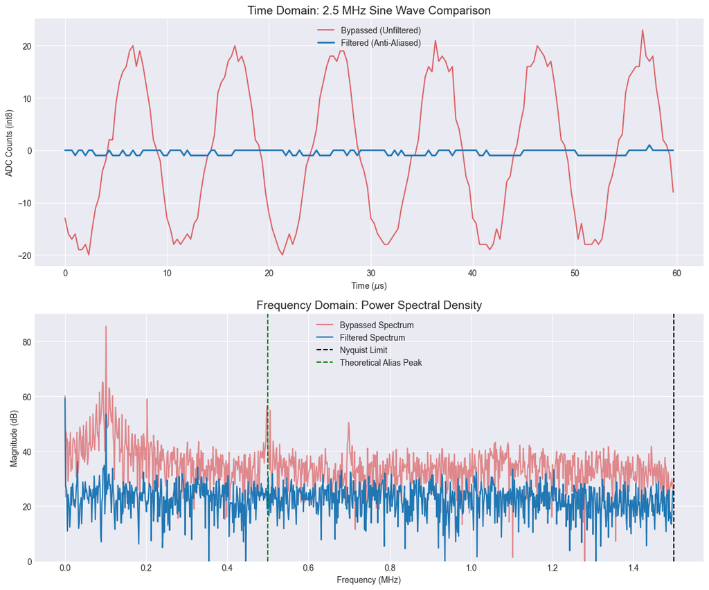

```python
fil = 'sinewave_test/sine_wave_2e6_rf/filtered_f2p500e06_sr3p000e06_20260205_110133.npz'
byp = 'sinewave_test/sine_wave_2e6_rf/bypassed_f2p500e06_sr3p000e06_20260205_110133.npz'

analyze = signal_tools.SignalAnalyzer(byp, fil)
analyze.plot_comparison(rf=2.5)
```

*Figure 1*. Time domain and power spectrum graph plotting a 2.5 MHz sine wave sampled at 3.0 MHz through an SDR. The red line represents the signal sampled without the SDR's anti-aliasing filter, which reconstructs a sinusoidal appearance at a 'ghost' (aliased) frequency that differs from the true signal frequency in the time domain as a result of Nyquist folding. The blue line is the sampled signal with anti-aliasing filters switched on, which appears 'flat' as a result of the SDR filtering out the entirety of the pure 2.5 MHz signal that lies above the Nyquist rate. The power spectrum graph visibly demonstrates how the SDR's anti-aliasing filter flattened the magnitude of the signal's power as compared to the bypassed signal.

Upon viewing the power spectrum graph, we note that the bypassed signal demonstrates peaks at 0.1 MHz and 0.5 MHz. We expect a theoretical alias peak at 0.5 MHz from the formula $f_a = |f_{in} - N \cdot f_sr|$, with $N=1$ representing the second Nyquist zone; the 0.1 MHz peak differs from theory, however. An unexpected peak at 0.1 MHz could be indicative of environmental or hardware electromagnetic interference, especially since the peak is visibly greater in magnitude as compared to the aliased peak at 0.5 MHz. Moreover, we may note that the filtered signal does not demonstrate a peak at 0.5 MHz—which lines up with the theoretical expectation of aliased frequency suppression—but does demonstrate the 0.1 MHz peak, which supports the idea that the peak may correspond to external interference rather than sampling aliasing.

We continue our analysis below in our sampling of the same 2.5 MHz sine wave at a sampling rate $f_{sr} = 2.5$ MHz:

```
Plot saved to comparison_plot.png
```

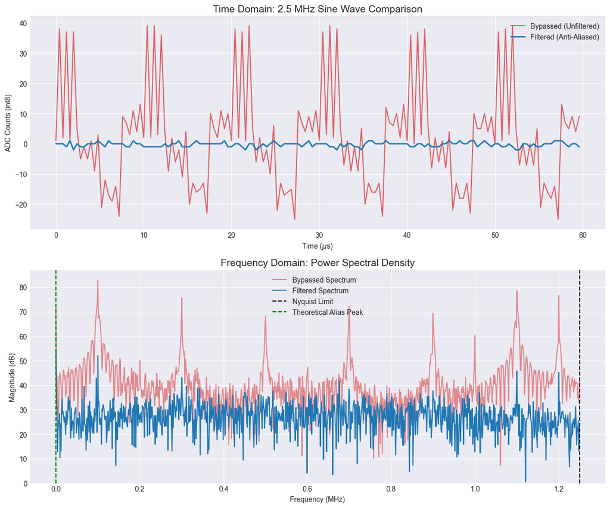

```python
byp2 = r"sinewave_test\sine_wave_2e6_rf\bypassed_f2p500e06_sr2p500e06_20260205_110132.npz"
fil2 = r"sinewave_test\sine_wave_2e6_rf\filtered_f2p500e06_sr2p500e06_20260205_110132.npz"
analyze2 = signal_tools.SignalAnalyzer(byp2, fil2)
analyze2.plot_comparison(rf=2.5)
```

*Figure 2*. Time domain and power spectrum graph plotting a 2.5 MHz sine wave sampled at 2.5 MHz through an SDR. The red line (bypassed) appears to be somewhat periodic but clearly non-sinusoidal, while the blue line (filtered) is flattened and resembles the theoretical random thermal noise floor of the SDR. Moreover, the bypassed signal demonstrates massive power peaks at multiples of 0.1 KHz, while the filtered signal demonstrates more flattened peaks at the same frequencies. Once again, the anti-alias filter appears to function correctly by flattening peaks, but the power spectra of both signals differ from theoretical expectations as discussed below.

The above results illustrate the discrepancy between ideal theory and real-world results. Mathematically, by sampling a supposedly pure sine wave at its own frequency, we would expect to record a constant signal. Upon applying a Fourier Transform to this signal, we would expect a singular delta spike centered at 0 Hz rather than the variable graph above. We may model our signal as a cosine wave (to maintain the expectation that its Fourier Transform is real-valued) as:

$$\large x(t) = A \cos(2\pi f_{rf} t + \phi)$$

Since we are sampling at $f_{rf} = f_{sr}$ and $t = \frac{n}{f_{sr}}$, we have: $$\large f_{rf} * t = f_{sr} * (\frac{n}{f_{sr}}) = n \implies x[n] = A \cos(2\pi n + \phi) = A \cos(\phi) = \text{constant}.$$

The Continuous Fourier Transform (CFT) of this constant value is: $$\mathcal{F}\{A \cos(\phi)\} = 2\pi A \cos(\phi) \delta(\omega)$$

I.e., a delta spike. Thus, we purport that the plots above are actually demonstrating harmonic aliasing as a result of a hardware voltage offset or internal clock discrepancy between the SDR and the function generator. If the spikes were true signals captured within the Nyquist sampling range, then the SDR anti-alias filter wouldn't have flattened the power spikes at the 0.1 MHz multiples—a true 0.1 MHz signal lands very safely in the SDR's bandpass filter range. Therefore, the SDR must be measuring—and flattening—some higher frequencies that lie outside of the bandpass filter; these peaks are aliased frequencies. Since the bandpass filter successfully flattened the 2.5 MHz signal as evident in the time domain, the periodic 0.1 MHz spikes in the frequency domain point toward the existence of harmonic frequencies in our sampled signal.

In other words, we are observing harmonic distortion as a result of hardware imperfections on part of the signal generator or SDR, or both. Suppose that the hardware contributes to some unknown frequency offset: $$\Delta{f} = |f_{true} - f_{m}|$$

Let $f_{true}$ and $f_m$ denote the true and measured signal generator output frequencies, respectively. Consider our aliasing formula: $f_{a} = |f_{rf} - nf_{sr}|$ where $n \in \mathbb{Z}$ is such that the aliased signal lands in the Nyquist range. If we set our aliased frequency to 0.1 MHz and assume folding occurs in the second Nyquist zone, we have:

$$0.1 \neq |2.5 - (1)(2.5)| = 0, \ \text{but} \ 0.1 = |2.5 \pm \Delta{f} - (1)(2.5)|$$ $$\implies \Delta{f} = \pm 0.1 \ \text{MHz} \implies f_{true} \in \{2.4, 2.6\}$$

Without a loss of generality on how the signal distorts across the time of output and time of digitization, we may say that the true signal output corresponds to 2.6 MHz rather than the expected 2.5 MHz. We can set $\tilde{f_{rf}} = 2.6 \ \text{MHz}$ to be our 'actual' frequency and calculate which power peaks correspond to which harmonic. A harmonic frequency is a multiple of the original signal, so we may write the formula for harmonic aliasing as:

$$\large f_{a} = |m\tilde{f_{rf}} - nf_{sr}| \ \text{where m is harmonic order and (n + 1) is the corresponding Nyquist zone.}$$

Consider the 0.3 MHz peak. From the formula above, we may deduce that the 0.1 MHz peak corresponds to the first harmonic frequency of the true signal. Suppose $m = 3$. We may compute that: $$f_a = 0.3 = |(3)(2.6) - n(2.5)| = |7.8 - n(2.5)| \implies n = 3.$$

```python
signal_tools.calculate_harmonic_aliases(f_sig=2.6, fs=2.5)
```

```
Harmonic   | Real Freq (MHz)  | Zone   | Alias (MHz)  | Type
-----------------------------------------------------------------
1          | 2.60             | 3      | 0.100        | Normal
2          | 5.20             | 5      | 0.200        | Normal
3          | 7.80             | 7      | 0.300        | Normal
4          | 10.40            | 9      | 0.400        | Normal
5          | 13.00            | 11     | 0.500        | Normal
6          | 15.60            | 13     | 0.600        | Normal
7          | 18.20            | 15     | 0.700        | Normal
8          | 20.80            | 17     | 0.800        | Normal
9          | 23.40            | 19     | 0.900        | Normal
10         | 26.00            | 21     | 1.000        | Normal
11         | 28.60            | 23     | 1.100        | Normal
12         | 31.20            | 25     | 1.200        | Normal
```

Observe that every harmonic falls into an odd Nyquist zone, so no harmonic aliases as an inverted signal; the power peaks are so large as a result of this phenomenon. The dominance of the odd harmonics (as opposed to even harmonics) in the power spectrum is a mathematical artifact of the half-wave symmetry property of the sine function, i.e.: $$f(t) = -f(t + T/2)$$

Since even harmonics break half-wave symmetry, their amplitudes are zero in a wave consisting only of sine functions. On the other hand, a wave consisting of pure cosines exhibits full-wave symmetry, so even harmonics survive while odd harmonics have zero amplitude. Another way to corroborate this property is by observing the Fourier Series representation of a signal comprised of only sine waves. Assuming that the signal generator outputs such a wave, the series representation may be written as: $$x(t) = \sum_{m=1,3,5...}^{\infty} A_m \sin(m\omega t + \phi_m)$$

The odd-numbered $m$ exactly map to the odd harmonics in a pure sine wave signal, where the coefficients $a_m$ determine the 'strength' of the corresponding alias peak in the frequency domain. The absence of even-numbered $m$ relate to the lack of even harmonic peaks and the half-wave symmetry.

Ideally, the function generator would output a singular pure sine wave that does not contain harmonic frequencies at all. Nevertheless, our measured signal is likely not a perfect singular sine wave—or even consisting purely of sine waves—but rather a slightly distorted signal comprised of both sines and cosines. Observe that the power spectrum above possesses spikes at $f_a = 1.0, 1.2 \ \text{MHz}$ as well, which are the aliased tenth and twelfth harmonic fequencies, respectively. Such even harmonics should not survive mathematically in the power spectrum if our signal was constructed solely from sine waves. Indeed, combining our sampled signal with its own half-shifted signal results in the constructive interference of even harmonics and destructive interference of odd harmonics:

```
Even Harmonics in Summed Signal:
  0.2 MHz: 56.00 dB (Original: 49.98 dB)
  0.4 MHz: 38.98 dB (Original: 32.96 dB)
  0.6 MHz: 53.32 dB (Original: 47.30 dB)
  0.8 MHz: 42.65 dB (Original: 36.63 dB)
  1.0 MHz: 50.94 dB (Original: 44.92 dB)
  1.2 MHz: 65.75 dB (Original: 59.73 dB)
```

```
np.float64(100097.65625)
```

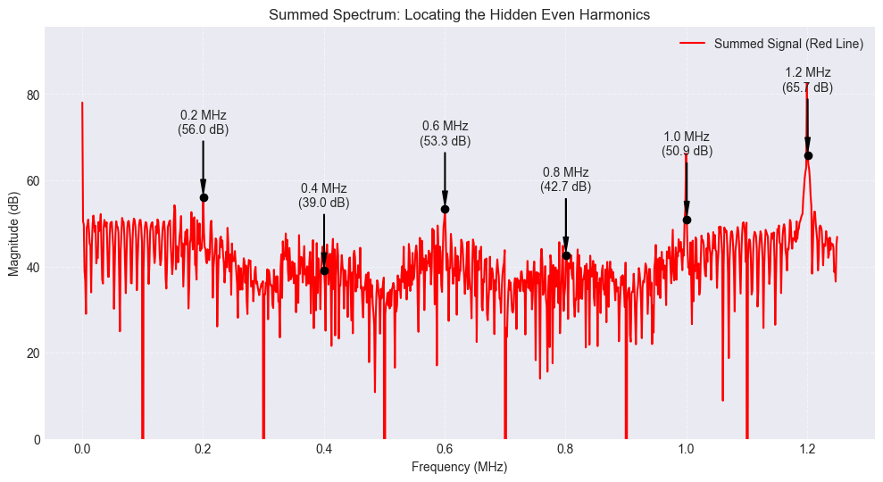

```python
signal_tools.analyze_even_harmonics('sinewave_test/sine_wave_2e6_rf/bypassed_f2p500e06_sr2p500e06_20260205_110132.npz')
```

*Figure 3*. Power spectrum of a 2.5 ($\pm 0.1$) MHz signal sampled at 2.5 MHz, phase-shifted by a half-period and recombined with its original self. The black arrows highlight the new apparent peaks at multiples of 0.2 MHz, corresponding to even harmonics which have increased in magnitude in the frequency domain due to constructive interference. Meanwhile, the frequencies at multiples of 0.1 MHz—corresponding to odd harmonics—exhibit massive downward spikes as a result of destructive interference. The half-wave symmetry property of a signal consisting mostly of sine waves manifests as the even-odd phenomena displayed in the graph.

From the graph above, the revealing of hidden even harmonics after an applied phase shift to the signal confirms that the function generator signal was distorted, either upon output or upon measurement. The above section serves to illustrate the limitations of analog hardware in producing and processing idealized signals, at least on the magnitude of ~1 MHz.

##### 1b) Voltage Spectrum Analysis

Consider the measurement of the 2.5 MHz radio frequency sampled at 3.0 MHz. We may compare the voltage spectra of the two samples with and without the use of the SDR's bandpass filter:

```
'voltage_spectrum.png'
```

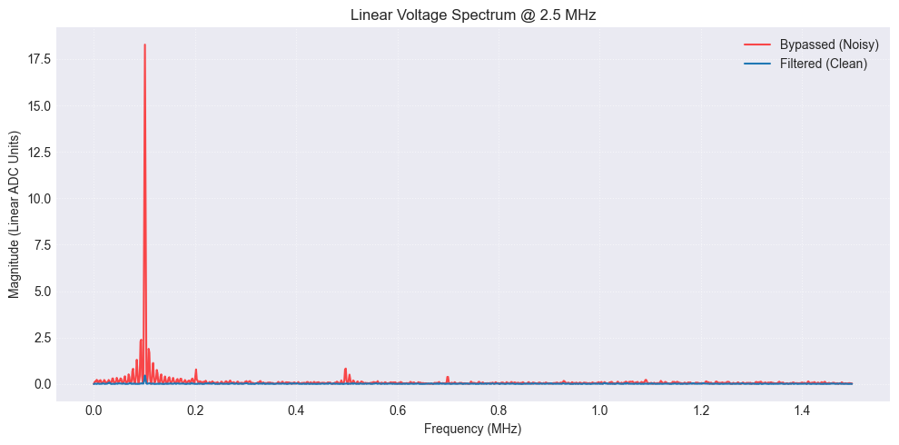

```python
analyze.plot_voltage_spectrum()
```

*Figure 4*. Voltage spectrum of a 2.5 ($\pm 0.1$) MHz signal sampled at 3.0 MHz with and without using the SDR's bandpass filter. A Hann window function was applied to the signal after subtracting its mean before plotting the spectrum. The bypassed signal (red) displays a massive spike at 0.1 MHz, corresponding to the spike in the power spectrum of Figure 1. There are several smaller spikes at various frequencies, including the location of the expected aliased signal at 0.5 MHz. The filtered signal (blue) successfully flattens the voltage spike at 0.1 MHz, but the peak remains apparent when compared to the remaining flatness of the filtered signal's voltage spectrum.

We observe a massive spike at 0.1 MHz with several smaller 'spikes' at 0.2, 0.5, and 0.7 MHz. Referring to Figure 1, the frequencies of these voltage spikes correspond to the power spikes, as expected. The main peculiarity to note is the massive difference in magnitude between the unexpected 0.1 MHz voltage spike and the expected 0.5 MHz voltage spike at the location of the aliased fundamental frequency. Theoretically, we should expect the spike at 0.5 MHz to be the largest in magnitude. The above results then reinforce the evidence pointing toward hardware-related discrepancies (i.e., a voltage or clock offset) in the signal processing.

### 3) Other Experimental Attempts

Included below are descriptions of our group's attempts at the remaining experimental portions of Lab 1.

##### 3a) Frequency Resolution Experiment (5.6)

Our group funneled two signal generator sine waves (differing ~5%) through a reverse power splitter into our SDR. Despite trying multiple configurations of direct sample, FIR coefficient and gain toggle settings, we were unable to sample any information that did not reduce to arrays containing the the elements -1, 0, and 1.

##### 3b) Noise Generator Experiment (5.8.1)

Our group sampled a laboratory noise generator with the attenuation knob set to various levels. Initial collected data defaulted to -1, 0, and 1. Eventually we were able to gather unique data; time did not permit for further analysis.

##### 3c) DSB Experiment (7.1)

Similarly to the frequency resolution experiment, we had largely collected arrays of -1, 0, and 1. While we had eventually collected some data with a larger number of unique elements, we unfortunately forgot to actually toggle the output setting to 'on' on the function generator generating our radio frequency.

[figure not shown]

##### 3d) SSB Experiment (7.3)

Issues include all of the above. We initally suffered the issue of only sampling -1, 0, and 1. We could not figure out how to properly sample or differentiate between the I and Q values since the two cables were separate. We had attempted to use a reverse power splitter to sample through the SDR, but the data again defaulted to -1, 0, and 1. Attempts to sample each cable separately did yield unique results, but at the end of the experimentation session we discovered that the radio frequency signal generator was in fact not outputting any signal.

[figure not shown]

In hindsight, the lack of output should have appeared obvious as demonstrated by the oscilloscope display. However, our group had erroneously understood the oscilloscope as displaying sum and difference frequencies as well as phase shifts.

[figure not shown]

# V. Conclusion

Based on the above analysis, we reject the null hypothesis that the SDR is effectively attenuating signals as expected. We did not observe a delta spike at 0 Hz when sampling a 2.5 MHz signal at 2.5 MHz, but instead unveiled hidden harmonic distortion in the signal. Moreover, our analysis of the power and voltage spectra suggested that internal hardware functions may be influencing the true radio frequency output that we measure.

In terms of overall reflection, our group as a whole found this lab to be incredibly difficult. The learning curve was very steep in terms of technical skills, but the knowledge gained was certainly worth it. With our newly developed skills in digital sampling methods, we will be much better prepared for the future labs in the course.